# Introduction

In this notebook I will be going through some of my used models, both from my personal exercises as models explored in my group project to try and get a better understanding of applying Explaiable AI within different kinds of models

To start of, I will be taking a look at GRAD Cam, I will use this to visually show a heatmap of the most important input pixels for my CNN model used in TrafficSigns and the BOI image recognition, as well as trying it on a fully pre-trained model with high accuracy, as this will help show the possible differences and observations that can be made from using this tool on less accurate models.

### Traffic Signs CNN

Below, I will try using the CNN trained with transferlearning on roadsigns, to create a Gradcam visualization of the POI taken by the model.  
Because, I did not save this model, I will have to retrain it first.

```python
import matplotlib.pyplot as plt
import numpy as np
from PIL import Image
import tensorflow as tf
import pandas as pd

from tensorflow import keras
```

Load the datasets

```python
image_size = (71, 71)

train_dataset = tf.keras.utils.image_dataset_from_directory(
    "../TrafficSignTransferredRecognition/Dataset/traffic_Data/DATA/",
    labels="inferred",
    subset="training",
    seed=123,
    validation_split=0.2)
val_dataset = tf.keras.utils.image_dataset_from_directory(
    "../TrafficSignTransferredRecognition/Dataset/traffic_Data/DATA/",
    labels="inferred",
    subset="validation",
    seed=123,
    validation_split=0.2)
test_dataset = tf.keras.utils.image_dataset_from_directory(
    "../TrafficSignTransferredRecognition/Dataset/traffic_Data/TEST_RESTRUCTURED/",
    labels="inferred",
    seed=123)



# get class name indexes
original_class_names = train_dataset.class_names
original_test_class_names = test_dataset.class_names
```

```
Found 4170 files belonging to 58 classes.
Using 3336 files for training.
Found 4170 files belonging to 58 classes.
Using 834 files for validation.
Found 1994 files belonging to 58 classes.
```

Create a key-value map to re-index the datasets, as tensorflow for some reason messes up the index count, by ordering alphabetically even if the classes are numeric...

```python
train_val_index_table = tf.lookup.StaticHashTable(
    initializer=tf.lookup.KeyValueTensorInitializer(
        keys=tf.constant(np.arange(len(original_class_names)), dtype=tf.int32),
        values=tf.constant(list(map(int, original_class_names)), dtype=tf.int32),
    ),
    default_value= tf.constant(len(original_class_names), dtype=tf.int32)
)

def re_index_labels(image, label):
    # Use the hash table to map old labels to new labels
    new_label = train_val_index_table.lookup(label)
    return image, new_label

train_dataset = train_dataset.map(re_index_labels)
val_dataset = val_dataset.map(re_index_labels)
test_dataset = test_dataset.map(re_index_labels)
```

Create label function to translate the index numbers to human readable labels using the provided labels csv

```python
csv_labels = pd.read_csv("../TrafficSignTransferredRecognition/Dataset/labels.csv")
csv_labels_dict = classid_to_name = dict(zip(csv_labels['ClassId'], csv_labels['Name']))
def relabel(label):
    return csv_labels_dict[int(label)]
```

Normalize all images to same input size

```python
# Resize the datasets
train_dataset = train_dataset.map(lambda x, y: (tf.image.resize(x, image_size), y))
val_dataset = val_dataset.map(lambda x, y: (tf.image.resize(x, image_size), y))
test_dataset = test_dataset.map(lambda x, y: (tf.image.resize(x, image_size), y))
```

Create the model.  
NOTE: This model actually has an additional Conv2D layer, as I will need to reference the last convolutional layer during Grad CAM heatmap generation, and if the last conv layer is inside the referenced pre-trained model, I will have to flatten those pre-trained layers into the parent model, which causes many issues with the connections between layers, to the point it is not worth the effort (While, I did spend a significant time getting that working, I ended up scratching it and do not have any of the code cells left, as they were not brought over from my testing notebook directly in the Traffic Signs ipynb to this notebook, but in short, flattening the layers destroys the Input layer for some reason causing the model to not be able to be built, but specifying a new input layer while building the flattened model, caused errors that I could only find might be caused by some internal model layer indexing issues).

```python
pretrained_model = keras.applications.Xception(
    weights='imagenet',  # Load weights pre-trained on ImageNet
    input_shape=(71, 71, 3), # Input shape of our dataset images
    include_top=False)  # Exclude the classifier layer, as our own will be used

pretrained_model.trainable = False

model = keras.Sequential(
    [
        keras.Input(shape=(71, 71, 3)),
        keras.layers.Rescaling(scale=1 / 127.5, offset=-1),
        pretrained_model,
        keras.layers.Conv2D(512, 3, padding='same', activation='relu'),
        keras.layers.GlobalAveragePooling2D(),
        keras.layers.Dense(len(original_class_names)),
    ])
```

```python
# # Flatten model function to move all layers into a single model instead of having model reference layers
# def flatten_model(model):
#     flattened_layers = []
#     for layer in model.layers:
#         try:
#             flattened_layers.extend(layer.layers)
#         except AttributeError:
#             flattened_layers.append(layer)
#     # flattened_layers.insert(0, keras.Input(shape=(71, 71, 3)))
#     flattened_model = keras.models.Sequential(flattened_layers)
#     return flattened_model
```

Train the model

```python
epochs = 10
model.compile(optimizer=keras.optimizers.Adam(),
              loss=keras.losses.SparseCategoricalCrossentropy(from_logits=True),
              metrics=['accuracy'])
try:
    model_train_history = model.fit(train_dataset, epochs=epochs, validation_data=val_dataset)
    print("completed training")
finally:
    model.save("models/TrafficSignCNN/")
    print("saved model")
```

Shortly evaluate the model, to get an idea of how well it should be at recognizing roadsigns (the original model got ~0.5% accuracy)

```python
model_metrics = model.evaluate(test_dataset, verbose=1)
```

Now, lets create the GRAD Cam heatmap, that can be used to visualize the pixel node activation of the model for a given image.  
For this I primarily followed this [Grad-cam guide](https://keras.io/examples/vision/grad_cam/), which goes over creating this heatmap for an xception model (which is what the traffic sign model used for transfer learning)

First, lets setup the logic that will go through the model and return a heatmap of the most prominently activated input pixels.  
NOTE: I am pretty sure the guide messes up and selects the wrong last convolutional layer, while this layer comes in later as an activation layer, it is not the final convolution layer (looking around on the internet it seems that my approach is more used), from my personal experimenting I found that selecting the final layer with my method actually returns a much more defined heatmap than the more generic activation layer.  
I am not sure if this indicates that I am actually selecting a single convolutional layer, and I would be better off selecting the final activation layer (but I was unable to find a programatical way of selecting this layer, as the prediction layer is also of activation type, while summary of the layers shows otherwise)

```python
def get_last_conv_layer(model):
    last_conv_layer = None
    for layer in reversed(model.layers):
        if 'conv2d' in layer.name.lower():  # Check if the layer is a convolutional layer
            last_conv_layer = layer
            break  # Stop after finding the last convolutional layer
    return last_conv_layer

def make_gradcam_heatmap(img_array, model, last_conv_layer_name, pred_index=None):
    # Create a new thin model, that exclusively takes the original model's input tensor (the image pixels),
    # and the model's last convolutional output values alongside it's normal output (the classification)
    grad_model = keras.models.Model(
        model.inputs, [model.get_layer(last_conv_layer_name).output, model.output]
    )

    # Then, we compute the gradient of the top predicted class for our input image
    # with respect to the activations of the last conv layer
    with tf.GradientTape() as tape:
        # Get the model's output of the last conv layer and prediction layer for given image
        last_conv_layer_output, preds = grad_model(img_array)
        if pred_index is None: # Find the predicted classification, by obtaining the highest activation node
            pred_index = tf.argmax(preds[0])
        class_channel = preds[:, pred_index] # Get the predicted class for every image in the batch

    grads = tape.gradient(class_channel, last_conv_layer_output) # Calculate the importance gradient for the final conv output layer in relation to the predicted classes,
                                                                 # this effectively merges all predictions and their conv layer outputs together to get a general idea of importance

    pooled_grads = tf.reduce_mean(grads, axis=(0, 1, 2)) # Reduce the multi dimensional gradient output into a single dimension to convert into 2D heatmap

    last_conv_layer_output = last_conv_layer_output[0] # Get the conv2d layer's feature map for the first image in the batch
    heatmap = last_conv_layer_output @ pooled_grads[..., tf.newaxis] # Calculate the dotproduct of the conv2d feature mapping against the gradient importance
    heatmap = tf.squeeze(heatmap) # Convert the heatmap to a 2D array

    heatmap = tf.maximum(heatmap, 0) / tf.math.reduce_max(heatmap) # Normalize the heatmap values between 0-1
    return heatmap.numpy()
```

Lets create one of these heatmaps

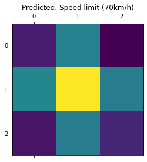

```python
# Get the first record batch
record = train_dataset.take(1)
image_arrays = None
image_labels = None
for image, label in record:
    image_arrays = image
    image_labels = label
predictions = model.predict(train_dataset.take(1))

# Get the last convolutional layer programatically
last_conv_layer = get_last_conv_layer(model)

# # Generate class activation heatmap
heatmap = make_gradcam_heatmap(image_arrays, model, last_conv_layer.name)

plt.matshow(heatmap)
plt.title(f"Predicted: {relabel(np.argmax(predictions[0]))}")
plt.show()
```

You can already see, a very big reason why the model performs very inefficiently, due to the extremely low 71x71 input size, throughout the model's MaxPooling (downsampling), the convolutional layers end up only having a 3x3 feature set to work with, which is most likely not big enough to notice small changes, such as the text on a sign

Lets overlay this heatmap on the image it was predicting

```python
import matplotlib
def apply_heatmap(heatmap, image_array, heatmap_opacity=0.4): # Returns image_array with heatmap as overlay
    heatmap = np.uint8(255 * heatmap) # Rescale heatmap to a range 0-255

    jet = matplotlib.colormaps["jet"] # Use jet colormap to colorize heatmap

    # Use RGB values of the colormap
    jet_colors = jet(np.arange(256))[:, :3]
    jet_heatmap = jet_colors[heatmap]

    # Create an image with RGB colorized heatmap
    jet_heatmap = keras.utils.array_to_img(jet_heatmap)
    jet_heatmap = jet_heatmap.resize((image_array.shape[1], image_array.shape[0]))
    jet_heatmap = keras.utils.img_to_array(jet_heatmap)

    # Superimpose the heatmap on original image
    superimposed_img_array = jet_heatmap * heatmap_opacity + image_array
    return keras.utils.array_to_img(superimposed_img_array)
```

```
(-0.5, 70.5, 70.5, -0.5)
```

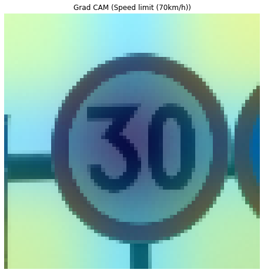

```python
# Add the heatmap to the original image
img = apply_heatmap(heatmap, image_arrays[0])

# # Display Grad CAM
plt.figure(figsize=(8, 8))
plt.title(f"Grad CAM ({relabel(np.argmax(predictions[0]))})")
plt.imshow(img)
plt.axis("off")
```

Exactly, as expected, the model predicted the general shape correctly (which most likely favors speed limit signs, as there are many speed limit signs in the dataset, due to every type of speedlimit having its own classification with images), but did not get any of the text inside the sign correct, causing it to guess the 30km/h sign as an 70km/h (which ofcourse would be terrible if used in for example, a self driving car, or even on google map's sometimes working speed limit indicator...)

### High accuracy CNN

Now that I have an idea of how the Grad-cam heatmaps should work, and I have a general idea of how to read it. I am very interested what it would look like on a **well trained** model with an acceptible accuracy, to see the differences.

For this, I will be using the pretrained Xception model, just as done in the guide mentioned earlier.

```python
imagenet_model = keras.applications.xception.Xception(weights="imagenet") # Get the Xception model API

# Get some general information needed later on to process data for the model
img_size = (299, 299)
preprocess_input = keras.applications.xception.preprocess_input
decode_predictions = keras.applications.xception.decode_predictions
```

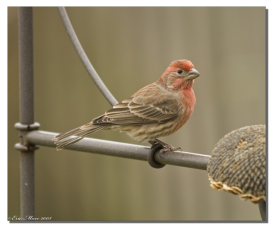

```python
# Get the image I will be using for the heatmap and prediction
img_path = keras.utils.get_file(
    "house_finch.jpg", "https://github.com/EliSchwartz/imagenet-sample-images/blob/master/n01532829_house_finch.JPEG?raw=true"
)

plt.imshow(keras.utils.load_img(img_path))
plt.axis("off")

img_array = keras.utils.img_to_array(keras.utils.load_img(img_path, target_size=img_size)) # Convert the image to an image array
img_batch = preprocess_input(np.expand_dims(img_array, axis=0)) # put the image into a batch array, for keras modelling
```

Please for the love of god, make sure to apply preprocess_input on the image you want to predict, otherwise the keras model will always think it is a mixing_bowl!!

```
(-0.5, 298.5, 298.5, -0.5)
```

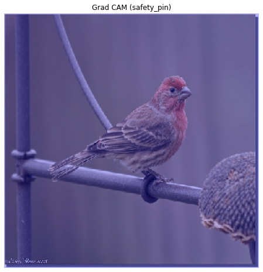

```python
predictions = imagenet_model.predict(img_batch)
# Get the last convolutional layer programatically
last_conv_layer = get_last_conv_layer(imagenet_model)

# Generate class activation heatmap
heatmap = make_gradcam_heatmap(img_batch, imagenet_model, "block14_sepconv2_act")

# Add the heatmap to the original image
img = apply_heatmap(heatmap, img_array)

# # Display Grad CAM
plt.figure(figsize=(8, 8))
plt.title(f"Grad CAM ({decode_predictions(predictions, top=1)[0][0][1]})")
plt.imshow(img)
plt.axis("off")
```

```python
imagenet_model.summary()
```

```
Model: "xception"
__________________________________________________________________________________________________
 Layer (type)                Output Shape                 Param #   Connected to
==================================================================================================
 input_3 (InputLayer)        [(None, 299, 299, 3)]        0         []

 block1_conv1 (Conv2D)       (None, 149, 149, 32)         864       ['input_3[0][0]']

 block1_conv1_bn (BatchNorm  (None, 149, 149, 32)         128       ['block1_conv1[0][0]']
 alization)

 block1_conv1_act (Activati  (None, 149, 149, 32)         0         ['block1_conv1_bn[0][0]']
 on)

 block1_conv2 (Conv2D)       (None, 147, 147, 64)         18432     ['block1_conv1_act[0][0]']

 block1_conv2_bn (BatchNorm  (None, 147, 147, 64)         256       ['block1_conv2[0][0]']
 alization)

 block1_conv2_act (Activati  (None, 147, 147, 64)         0         ['block1_conv2_bn[0][0]']
 on)

 block2_sepconv1 (Separable  (None, 147, 147, 128)        8768      ['block1_conv2_act[0][0]']
 Conv2D)

 block2_sepconv1_bn (BatchN  (None, 147, 147, 128)        512       ['block2_sepconv1[0][0]']
 ormalization)

 block2_sepconv2_act (Activ  (None, 147, 147, 128)        0         ['block2_sepconv1_bn[0][0]']
 ation)

 block2_sepconv2 (Separable  (None, 147, 147, 128)        17536     ['block2_sepconv2_act[0][0]']
 Conv2D)

 block2_sepconv2_bn (BatchN  (None, 147, 147, 128)        512       ['block2_sepconv2[0][0]']
 ormalization)

 conv2d_8 (Conv2D)           (None, 74, 74, 128)          8192      ['block1_conv2_act[0][0]']

 block2_pool (MaxPooling2D)  (None, 74, 74, 128)          0         ['block2_sepconv2_bn[0][0]']
```

[output cut: 349 more lines]

```
 Normalization)

 block14_sepconv2_act (Acti  (None, 10, 10, 2048)         0         ['block14_sepconv2_bn[0][0]']
 vation)

 avg_pool (GlobalAveragePoo  (None, 2048)                 0         ['block14_sepconv2_act[0][0]']
 ling2D)

 predictions (Dense)         (None, 1000)                 2049000   ['avg_pool[0][0]']

==================================================================================================
Total params: 22910480 (87.40 MB)
Trainable params: 22855952 (87.19 MB)
Non-trainable params: 54528 (213.00 KB)
__________________________________________________________________________________________________
```

```
(-0.5, 298.5, 298.5, -0.5)
```

[figure not shown]

```python
predictions = imagenet_model.predict(img_batch)
# Get the last convolutional layer programatically
last_conv_layer = get_last_conv_layer(imagenet_model)

# Generate class activation heatmap
heatmap = make_gradcam_heatmap(img_batch, imagenet_model, last_conv_layer.name)

# Add the heatmap to the original image
img = apply_heatmap(heatmap, img_array, heatmap_opacity=0.01)

# # Display Grad CAM
plt.figure(figsize=(8, 8))
plt.title(f"Grad CAM ({decode_predictions(predictions, top=1)[0][0][1]})")
plt.imshow(img)
plt.axis("off")
```

```
(-0.5, 298.5, 298.5, -0.5)
```

[figure not shown]

```python
# Generate class activation heatmap
heatmap = make_gradcam_heatmap(img_batch, imagenet_model, "block14_sepconv2_act")

# Add the heatmap to the original image
img = apply_heatmap(heatmap, img_array, heatmap_opacity=0.01)

# # Display Grad CAM
plt.figure(figsize=(8, 8))
plt.title(f"Grad CAM ({decode_predictions(predictions, top=1)[0][0][1]})")
plt.imshow(img)
plt.axis("off")
```

As mentioned before, I am not 100% sure what layer to select as the final convolutional layer, while I do think the top image is much more interesting as it seems like the model is paying attention to the chest of the bird as it has a distinct color and might help identify it against other birds.  
This thought process does indicate however, that using my programatic approach to obtaining the final conv layer, actually shows the activation of that feature layer, while the image below shows the geral area of interest for the model which is more in line with generic Grad-cam usage.

That does give me the idea, that I might be able to create a subplot list of all conv layers and see what each layers is paying attention to in the model, so lets try that!

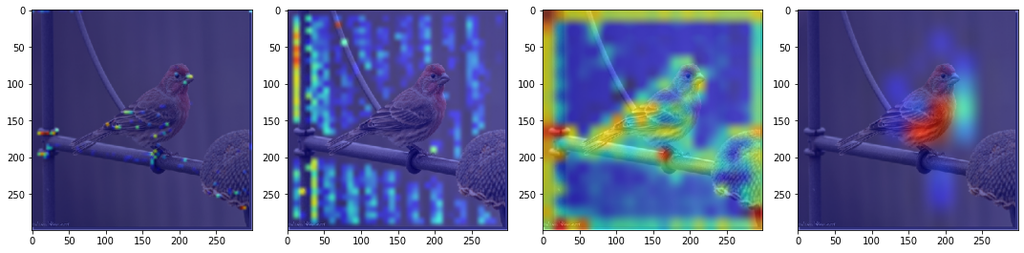

```python
conv_layers = []
for layer in imagenet_model.layers:
    if 'conv2d' in layer.name.lower():  # Check if the layer is a convolutional layer
        conv_layers.append(layer)

fig, axes = plt.subplots(1, len(conv_layers), figsize=(15, 5))

i = 0
for conv_layer in conv_layers:
    # Generate class activation heatmap
    heatmap = make_gradcam_heatmap(img_batch, imagenet_model, conv_layer.name)

    # Add the heatmap to the original image
    img = apply_heatmap(heatmap, img_array, heatmap_opacity=0.01)

    # Display the subplot
    axes[i].imshow(img)
    i += 1

plt.tight_layout()
plt.show()
```

Yep, my assumption seems to have proven correctly, and this shows some really cool visualization of the 4 convolutional layers in the Xception layer, and how they were activated based on the image, with the second layer actually clearly paying attention to the background instead of the bird itself.

This did prove that my get_last_conv_layer was getting the actual feature layer instead of the final activation layer, so I have adjusted the method below.

```python
def get_last_conv_activation_layer(model):
    last_conv_layer = None
    for layer in reversed(model.layers):
        if 'conv2' in layer.name.lower():  # Check if the layer is a convolutional layer
            last_conv_layer = layer
            break  # Stop after finding the last convolutional layer
    return last_conv_layer
```

Out of curiosity, I also want to just plot one of these heatmaps that are later superimposed on the image, as the traffic sign CNN was 3x3 which I assumed was due to the immense downsampling that was done throughout the layers due to starting with the small 71x71 size (which makes me understand why that was the minimum size now, as any smaller and the later conv layers wouldn't even have anything to work with).

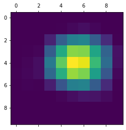

```python
predictions = imagenet_model.predict(img_batch)
# Get the last convolutional layer programatically
last_conv_layer = get_last_conv_activation_layer(imagenet_model)

# Generate class activation heatmap
heatmap = make_gradcam_heatmap(img_batch, imagenet_model, last_conv_layer.name)

# Show the heatmap
plt.matshow(heatmap)
```

### BOI CNN

I also want to take a quick look at my BOI CNN model that I previously used as part of my ANN exercise, as I spent a very long time figuring out why the training and validation datasets were giving very high accuracy, while new images were not.

```python
img_size = (32, 32)

train_ds = tf.keras.utils.image_dataset_from_directory(
  "../BOIANNRecognition/collectible-icons-subset/",
  validation_split=0.2,
  subset="training",
  labels="inferred",
  seed=42,
  image_size=img_size)

val_ds = tf.keras.utils.image_dataset_from_directory(
  "../BOIANNRecognition/collectible-icons-subset/",
  validation_split=0.2,
  subset="validation",
  labels="inferred",
  seed=42,
  image_size=img_size)

class_names = train_ds.class_names

# Split the train set into also a test set
test_ds = train_ds.skip(int(0.2 * len(train_ds)))
train_ds = train_ds.take(int((1 - 0.2) * len(train_ds)))
```

```
Found 2000 files belonging to 10 classes.
Using 1600 files for training.
Using 1600 files for training.
Found 2000 files belonging to 10 classes.
Using 400 files for validation.
```

Check that the image data labels are not messed up, as that now gives me flashbacks to the traffic sign dataset D:

[figure not shown]

```python
plt.figure(figsize=(10, 10))
for images, labels in train_ds.take(1):
    for i in range(25):
        ax = plt.subplot(5, 5, i + 1)
        plt.imshow(images[i].numpy().astype("uint8"))
        plt.title(class_names[labels[i]])
        plt.axis("off")
```

```python
num_sub_classes = len(class_names)

boi_model = keras.Sequential([
  keras.layers.Rescaling(1./255, input_shape=(32, 32, 3)),
  keras.layers.Conv2D(16, 3, padding='same', activation='relu'),
  keras.layers.MaxPooling2D(),
  keras.layers.Flatten(),
  keras.layers.Dense(16, activation='relu'),
  keras.layers.Dense(num_sub_classes)
])

boi_model.compile(optimizer='adam',
              loss=tf.keras.losses.SparseCategoricalCrossentropy(from_logits=True),
              metrics=['accuracy'])

epochs=10
try:
  history = boi_model.fit(
    train_ds,
    validation_data=val_ds,
    epochs=epochs
  )
finally:
  boi_model.save("models/BOICNN/")
  print("model saved")
```

```
INFO:tensorflow:Assets written to: models/BOICNN/assets
```

```
INFO:tensorflow:Assets written to: models/BOICNN/assets
```

```
model saved
```

```python
relabeled_metrics = boi_model.evaluate(test_ds, verbose=1)
```

Now let's do the Grad CAM again, which I should be an expert at at this point

First, lets create a method that can turn the black background of an image into a white one

```python
def image_array_black_to_white(img_array):
    # First normalize the image array into a numpy array by translating it into a PIL Image first
    image_array = np.array(keras.utils.array_to_img(img_array))
    # Create a mask for the black pixels and convert them to white
    black_mask = np.all(image_array == (0, 0, 0), axis=-1)
    image_array[black_mask] = (255, 255, 255)
    return image_array
```

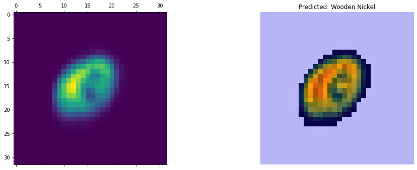

```python
# Get the first record batch
record = test_ds.take(1)
image_arrays = None
image_labels = None
for image, label in record:
    image_arrays = image
    image_labels = label
predictions = boi_model.predict(image_arrays)

# Get the last convolutional layer programatically
last_conv_layer = get_last_conv_activation_layer(boi_model)

# preprocess the first image
image_array = image_array_black_to_white(image_arrays[0])
# # Generate class activation heatmap
heatmap = make_gradcam_heatmap(image_arrays, boi_model, last_conv_layer.name)

# Add the heatmap to the original image
img = apply_heatmap(heatmap, image_array, heatmap_opacity=0.4)

predicted_class = class_names[np.argmax(predictions[0])]

fig, axes = plt.subplots(1, 2, figsize=(15, 5))
axes[0].matshow(heatmap)
axes[1].imshow(img)

plt.tight_layout()
plt.title(f"Predicted: {predicted_class}")
plt.axis("off")
plt.show()
```

From the heatmap and GRAD CAM above, it is actually visible that the conv activation is extremely precise for the image which would go to prove the very high accuracy.  
NOTE: do not perform take(1) multiple times and expect the same batch to be returned, this caused me many headaches, trying to figure out why the activation looked so nicely but the predicted image was incorrect (the prediction and image/heatmap used two different takes).  
This might also be an indicator of why the relatively small model performed so well on this dataset, but not on any new images I created myself in the game (as this was an issue I spent a while investigating in the BIOANN research) this probably means that the model is extremely overfitted to recognizing the images from the train/test dataset which are very uniform in the shapes and possible distortions

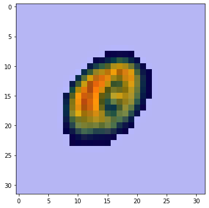

```python
conv_layers = []
for layer in boi_model.layers:
    if 'conv2d' in layer.name.lower():  # Check if the layer is a convolutional layer
        conv_layers.append(layer)

fig, axes = plt.subplots(1, len(conv_layers), figsize=(15, 5))

i = 0
for conv_layer in conv_layers:
    # Generate class activation heatmap
    heatmap = make_gradcam_heatmap(image_arrays, boi_model, conv_layer.name)

    # Add the heatmap to the original image
    image_array = image_array_black_to_white(image_arrays[0])
    img = apply_heatmap(heatmap, image_array, heatmap_opacity=0.4)

    # Display the subplot
    if (len(conv_layers) == 1):
        axes.imshow(img)
    else:
        axes[i].imshow(img)
    i += 1

plt.tight_layout()
plt.show()
```

Above I tried rendering all the conv2d layers, but as expected as I created the model, there is only one

[figure not shown]

```python
# Get the last convolutional layer programatically
last_conv_layer = get_last_conv_layer(boi_model)

plt.figure(figsize=(10, 10))
for images, labels in test_ds.take(1):
    predictions = boi_model.predict(images)
    for i in range(25):
        ax = plt.subplot(5, 5, i + 1)

        # preprocess the first image
        image_array = image_array_black_to_white(images[i])
        # # Generate class activation heatmap
        heatmap = make_gradcam_heatmap(images[i:], boi_model, last_conv_layer.name)

        # Add the heatmap to the original image
        img = apply_heatmap(heatmap, image_array, heatmap_opacity=0.6)

        predicted_class = class_names[np.argmax(predictions[i])]
        plt.title(predicted_class)
        plt.imshow(img)
        plt.axis("off")
```

Above I have created a matrix of these GRAD-cams and as expected, for every prediction the conv layer was extremely effective at isolating the image, even between image distortions.

Below, I have done the same test as in the BIOANN exploration, and given it an image of my own, with no processing done.

```
(-0.5, 84.5, 68.5, -0.5)
```

[figure not shown]

```python
test_img = np.asarray(Image.open("../BOIANNRecognition/ann_image_test_scorpio.png"))
plt.imshow(test_img)
plt.axis("off")
```

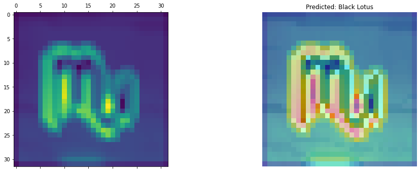

```python
test_img = tf.keras.utils.load_img("../BOIANNRecognition/ann_image_test_scorpio.png", target_size=(32, 32))
test_img_array = tf.keras.utils.img_to_array(test_img)
test_img_batch = tf.expand_dims(test_img, 0) # Create a batch
predictions = boi_model.predict(test_img_batch)

# Get the last convolutional layer programatically
last_conv_layer = get_last_conv_layer(boi_model)

# Generate class activation heatmap
heatmap = make_gradcam_heatmap(test_img_batch, boi_model, last_conv_layer.name)

# Add the heatmap to the original image
img = apply_heatmap(heatmap, test_img_array, heatmap_opacity=0.4)

predicted_class = class_names[np.argmax(predictions[0])]

fig, axes = plt.subplots(1, 2, figsize=(15, 5))
axes[0].matshow(heatmap)
axes[1].imshow(img)

plt.tight_layout()
plt.title(f"Predicted: {predicted_class}")
plt.axis("off")
plt.show()
```

```python
predictions
```

```
array([[-54.015686,  38.938206, -21.864874, -35.775425,  -7.147221,
          8.440993,  15.099087,  22.946325,  27.66841 ,   7.213704]],
      dtype=float32)
```

```python
indexed_array = list(enumerate(predictions[0]))
sorted_indexed_array = sorted(indexed_array, key=lambda x: x[1], reverse=True)
sorted_indexes = [index for index, _ in sorted_indexed_array]

for i, index in enumerate(sorted_indexes):
    print(f"{i+1}) {class_names[index]}")
```

```
1) Black Lotus
2) The Nail
3) Speed Ball
4) Scorpio
5) Moms Heels
6) Wooden Nickel
7) Infestation 2
8) Chocolate Milk
9) Cube of Meat
10) 120 Volt
```

```python
sorted_indexed_array
```

```
[(1, 38.938206),
 (8, 27.66841),
 (7, 22.946325),
 (6, 15.099087),
 (5, 8.440993),
 (9, 7.213704),
 (4, -7.147221),
 (2, -21.864874),
 (3, -35.775425),
 (0, -54.015686)]
```

While it wasn't correct in it's prediction, looking at all possible predictions and confidence values, it was not completely wrong, with the correct class coming in as the 4th highest class (which certainly isn't great but could be worse)

For good measure, lets do another image

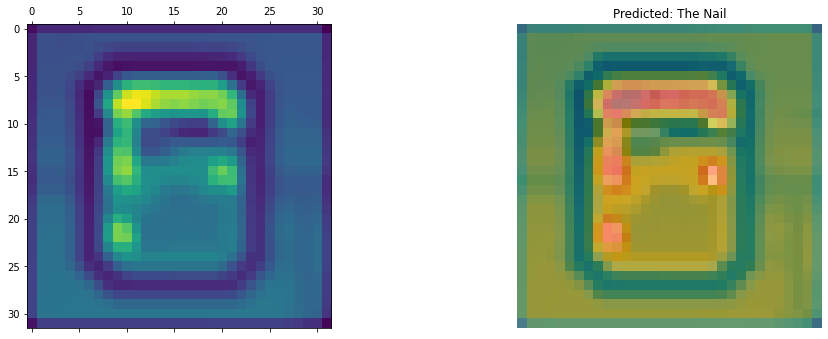

```python
test_img = tf.keras.utils.load_img("../BOIANNRecognition/ann_image_test_chocolate_milk.png", target_size=(32, 32))
test_img_array = tf.keras.utils.img_to_array(test_img)
test_img_batch = tf.expand_dims(test_img, 0) # Create a batch
predictions = boi_model.predict(test_img_batch)

# Get the last convolutional layer programatically
last_conv_layer = get_last_conv_layer(boi_model)

# Generate class activation heatmap
heatmap = make_gradcam_heatmap(test_img_batch, boi_model, last_conv_layer.name)

# Add the heatmap to the original image
img = apply_heatmap(heatmap, test_img_array, heatmap_opacity=0.4)

predicted_class = class_names[np.argmax(predictions[0])]

fig, axes = plt.subplots(1, 2, figsize=(15, 5))
axes[0].matshow(heatmap)
axes[1].imshow(img)

plt.tight_layout()
plt.title(f"Predicted: {predicted_class}")
plt.axis("off")
plt.show()
```

Looking at the images and heatmaps above, it seems like the heatmap might not be as perfect, but still follows the general outline of the items

After deliberating these results for a while, I think the conv layer might actually be looking at the color value of the image and thereby activates more on higher intensity colors such as white or blue, this would work very well for this image set as all items have generally different colors and very specific shapes

To test out this theory, I have modified the scorpio image as follows:

```
(-0.5, 84.5, 68.5, -0.5)
```

[figure not shown]

```python
modified_img = np.asarray(Image.open("../BOIANNRecognition/ann_image_test_scorpio_modified.png"))
plt.imshow(modified_img)
plt.axis("off")
```

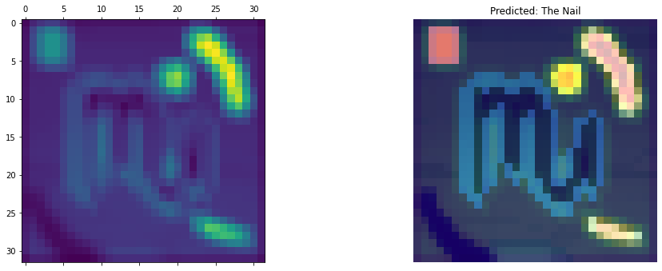

```python
test_img = tf.keras.utils.load_img("../BOIANNRecognition/ann_image_test_scorpio_modified.png", target_size=(32, 32))
test_img_array = tf.keras.utils.img_to_array(test_img)
test_img_batch = tf.expand_dims(test_img, 0) # Create a batch
predictions = boi_model.predict(test_img_batch)

# Get the last convolutional layer programatically
last_conv_layer = get_last_conv_layer(boi_model)

# Generate class activation heatmap
heatmap = make_gradcam_heatmap(test_img_batch, boi_model, last_conv_layer.name)

# Add the heatmap to the original image
img = apply_heatmap(heatmap, test_img_array, heatmap_opacity=0.4)

predicted_class = class_names[np.argmax(predictions[0])]

fig, axes = plt.subplots(1, 2, figsize=(15, 5))
axes[0].matshow(heatmap)
axes[1].imshow(img)

plt.tight_layout()
plt.title(f"Predicted: {predicted_class}")
plt.axis("off")
plt.show()
```

After running the GRAD-Cam again, it seems pretty clear that my theory was correct, with the areas on the image with a higher RGB value giving a higher activation of the conv layers (note, currently I am taking the last actual conv2d layer, not the final activation layer, but these are identical in this case, as there is only a single conv layer)

### SHAP values

Next I want to take a quick look at my OneClassSVM model from the group project, I will look into this model using the SHAP library, this library should be able to give me SHAP values that represent the contribution the feature had to the prediction. I am not 100% sure how this system works for anomaly detection, as from looking around it seems to not really be used for this usecase, but I think it is cool looking into it anyway.

As always, I forgot to save the model I want to use, so I will have to train it again. The model I will be looking at is not the best model I was able to produce using OneClassSVM, but instead it was a trial model to see what happens when I included features that I knew would be poisoneaus to the model's performance if it focussed on those features.  
To my suprise however, it seemed that the model completely ignored the features however which I want to learn more about.

```python
import pandas as pd
import numpy as np
from sklearn.svm import OneClassSVM
from sklearn.linear_model import SGDOneClassSVM
from sklearn.model_selection import train_test_split
```

```python
df = pd.read_csv('../../sueai/data/elastic_february2022_data.csv')
```

```python
mf_df = df[['_source_flow_final', '_source_network_bytes', '_source_event_duration', '_source_destination_port', '_source_source_port', 'label']]
mf_df = mf_df.dropna()
# Split df in benign/malicious
benign_mf_df = mf_df[mf_df['label'] == 'benign']
malicious_mf_df = mf_df[mf_df['label'] == 'malicious']

# Split benign into train/test
X_train, X_benign_test, y_train, y_benign_test = train_test_split(benign_mf_df[['_source_flow_final', '_source_network_bytes', '_source_event_duration', '_source_destination_port', '_source_source_port']].values.reshape(-1, 5), benign_mf_df['label'], test_size=0.2, random_state=42)

# Add the malicious data back into the test split
X_test = np.vstack((X_benign_test, malicious_mf_df[['_source_flow_final', '_source_network_bytes', '_source_event_duration', '_source_destination_port', '_source_source_port']].values.reshape(-1, 5)))
y_test = pd.concat([y_benign_test, malicious_mf_df['label']])

# Compile and train the model
# sigmoid_full_feature_model = OneClassSVM(kernel="sigmoid", nu=0.4)
SGD_model = SGDOneClassSVM(nu=0.4)
SGD_model.fit(X_train)
```

```
SGDOneClassSVM(nu=0.4)
```

Now that the model is trained, lets compute the SHAP values using the SHAP kernel explainer

```python
import shap
```

```python
shap_df = df[['_source_flow_final', '_source_network_bytes', '_source_event_duration', '_source_destination_port', '_source_source_port']].dropna()
```

```python
len(shap_df)
```

```
395857
```

```python
shap_df_subset = shap_df.sample(n=1000, random_state=42)
```

I am forced to create my own kernel explainer, as the computation done for OneClassSVM is different from the commonly used models such as normal SVMs

```python
explainer = shap.KernelExplainer(SGD_model.decision_function, data=shap_df_subset)
```

```
Using 1000 background data samples could cause slower run times. Consider using shap.sample(data, K) or shap.kmeans(data, K) to summarize the background as K samples.
```

```python
shap_values = explainer.shap_values(shap_df_subset)
```

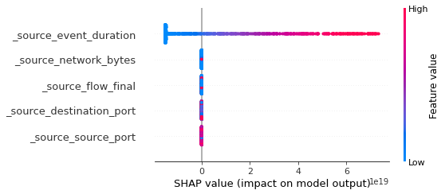

```python
shap.summary_plot(shap_values, shap_df_subset)
```

While, this proves some of my initial thoughts on how the model was training to learn the outlier boundary, the SGD kernel is actually not the kernel that will be used, due to it's mediocre performance in the SUE use-case, instead sigmoid is used which is a far more computationally intensive training model, so I will be training this model next to evaluate further using XAI

```python
# Train the sigmoid OneClassSVM model
sigmoid_model = OneClassSVM(kernel="sigmoid", nu=0.4)
sigmoid_model.fit(X_train)
```

```
OneClassSVM(kernel='sigmoid', nu=0.4)
```

Lets also save the model (due to kernel lock-up I've had to re-train this model 5 times already)

```python
from joblib import dump
dump(sigmoid_model, "models/OCSVM/sigmoid.joblib")
```

```
['models/OCSVM/sigmoid.joblib']
```

```python
# Sample the data to be smaller for the explainer
background_samples = shap.utils.sample(X_test, nsamples=100, random_state=24)
shap_samples = shap.utils.sample(X_test, nsamples=100, random_state=25)
# Initialize the explainer
explainer = shap.KernelExplainer(sigmoid_model.decision_function, data=background_samples)
# Calculate the SHAP values
try:
    shap_values = explainer.shap_values(shap_samples)
except KeyboardInterrupt:
    print("Cell was stopped")
```

Getting the shap_values for this model takes significantly longer than the previous SGD model, this makes sense as one of the major downsides of these kinds of OneClassSVM models, is that not only training takes extremely long compared to similar models, but predicting does too.

```python
shap_features = ['_source_flow_final', '_source_network_bytes', '_source_event_duration', '_source_destination_port', '_source_source_port']
```

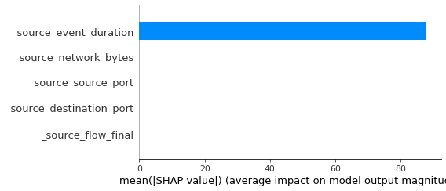

```python
shap.summary_plot(shap_values, shap_samples, plot_type="bar", feature_names=shap_features) # Show it in the form of a bar chart instead
```

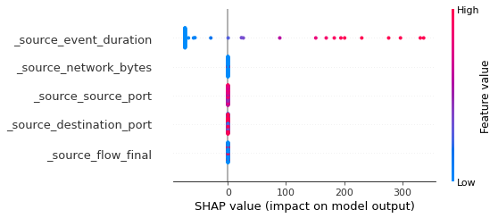

```python
shap.summary_plot(shap_values, shap_samples, feature_names=shap_features) # show summary graph of the shap values against the features
```

Just as the SGD model, only the _source_event_duration seemed to have any impact on the model whatsoever.  
Looking at the second chart, you can also see that a lower event_duration has a negative impact on the output, which equates to returning an outlier value instead of an inlier

Below, I tried to get a dependency plot working for the _source_event_duration feature, but because my model was trained without the feature headers (on a np.array, instead of a dataframe), the partial_depence_plot is unable to get a proper index to target that feature sadly.

```python
# Convert the shap_samples to a dataframe so I can query on feature
shap_samples_df = pd.DataFrame(data=shap_samples, columns=shap_features)
```

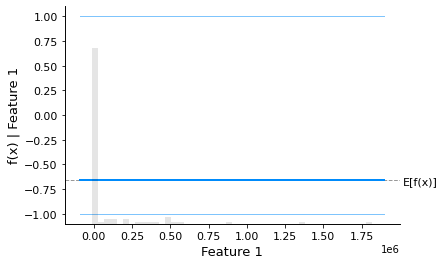

```
Code block interupted
```

[output not shown]

```python
try:
    pdp_values, pdp_feature_values = shap.partial_dependence_plot(1, sigmoid_model.predict, shap_samples,
                                                                  model_expected_value=True)
finally:
    print("Code block interupted")
```

Lastly, I will be visualizing the decision scores for the samples that I have been using to calculate the SHAP values, as this can give further insight into the model, as it can help show where the model set the decision boundary between benign and malicious, and in a worse case could show that the SHAP value sample set might have not had a diverse enough feature range, which is definitely possible due to the very limited sample size used.

```python
decision_scores = sigmoid_model.decision_function(shap_samples)
```

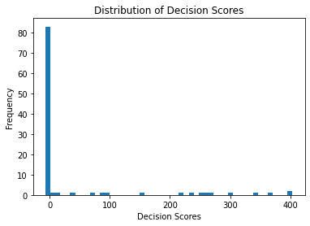

```python
import matplotlib.pyplot as plt

plt.hist(decision_scores, bins=50)
plt.xlabel('Decision Scores')
plt.ylabel('Frequency')
plt.title('Distribution of Decision Scores')
plt.show()
```

```python
shap_samples_df['_source_event_duration_log'] = shap_samples_df["_source_event_duration"].apply(lambda x: np.log(x) if x > 0 else 0)
shap_samples_df['_source_network_bytes_log'] = shap_samples_df["_source_network_bytes"].apply(lambda x: np.log(x) if x > 0 else 0)
```

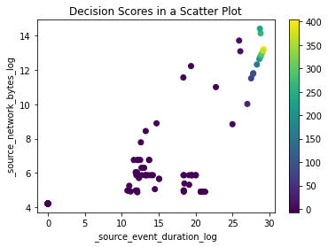

```python
plt.scatter(shap_samples_df["_source_event_duration_log"], shap_samples_df["_source_network_bytes_log"], c=decision_scores, cmap='viridis')
plt.colorbar()
plt.xlabel("_source_event_duration_log")
plt.ylabel("_source_network_bytes_log")
plt.title('Decision Scores in a Scatter Plot')
plt.show()
```

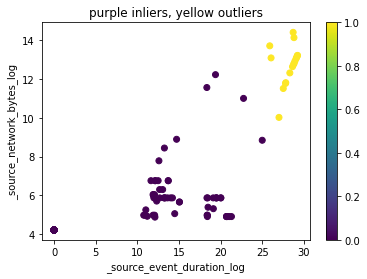

```python
is_outlier = decision_scores > 0
plt.scatter(shap_samples_df["_source_event_duration_log"], shap_samples_df["_source_network_bytes_log"], c=is_outlier, cmap='viridis')
plt.colorbar()
plt.xlabel("_source_event_duration_log")
plt.ylabel("_source_network_bytes_log")
plt.title("purple inliers, yellow outliers")
plt.show()
```

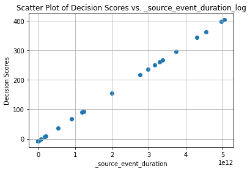

```python
plt.scatter(shap_samples_df['_source_event_duration'], decision_scores)
plt.xlabel('_source_event_duration')
plt.ylabel('Decision Scores')
plt.title('Scatter Plot of Decision Scores vs. _source_event_duration_log')
plt.grid(True)
plt.show()
```

From the plots above, you can get a slightly better idea of where the decision boundary is between the features.  
The last plot here is especially, interesting knowing that the model basically only took the _source_event_duration into account, the decision scores is linearly correlated with the _source_event_duration, which makes sense when considering that One-class SVM tries to find this correlation on it's own and if it ends up only taking one feature into account, the relation between the decision score and that feature would be linearly related.  
Which I suppose was a very smart way for the model to get a good performance for the given dataset, as it seemed to have found that exploiting the data this way was acceptible (very similar to something a neural network might do which is pretty cool).

Convert the shap_samples_df to also include the labels, for possible future evaluation

```python
# Create the labeled dataframe
labelled_shap_samples_df_features = shap_features + ["label"]
labelled_shap_samples_df = pd.DataFrame(columns=labelled_shap_samples_df_features)
for idx, row in shap_samples_df.iterrows():

    # Select only the common features in both DataFrames
    shap_samples_common = shap_samples_df[shap_features]
    mf_common = mf_df[shap_features]

    # Create a boolean mask to filter mf_common for matching records
    mask = (mf_common == shap_samples_common).all(axis=1)

    # Extract the matching records from mf_common
    matching_records = mf_common[mask]

    # Display the matching records with all features
    matching_records_full = mf_df[mask]

    # Display the matching records
    labelled_shap_samples_df = pd.concat([labelled_shap_samples_df, matching_records_full.head(1)], ignore_index=True)
```